# 1-5_ClimateWins_DT_ANNs

```python
import pandas as pd
import numpy as np
import seaborn as sns
import os
import operator
import matplotlib.pyplot as plt
from sklearn import datasets
from sklearn import metrics
from sklearn import tree
from sklearn.neural_network import MLPClassifier
from sklearn.model_selection import train_test_split
from sklearn.model_selection import train_test_split, cross_val_score
from sklearn.tree import DecisionTreeClassifier
from sklearn.metrics import multilabel_confusion_matrix, accuracy_score, confusion_matrix, ConfusionMatrixDisplay
from sklearn.preprocessing import StandardScaler
from matplotlib.pyplot import figure
```

```python
path = r'C:\Users\jinu5\Desktop\careerfoundry\ML\DataSet\original data'
```

```python
df = pd.read_csv(os.path.join(path, 'Dataset-weather-prediction-dataset-processed.csv'), index_col=False)
```

```python
# For training model, reading the dataset which includes 'What day was pleasant in each locations?'
df_y = pd.read_csv(os.path.join(path, 'Dataset-Answers-Weather_Prediction_Pleasant_Weather.csv'), index_col=False)
```

```python
# listing the location names from df
locations_A = list({x.split("_")[0] for x in df.columns if x not in ["MONTH", "DATE"]})
locations_A.sort()
locations_A
```

```
['BASEL',
 'BELGRADE',
 'BUDAPEST',
 'DEBILT',
 'DUSSELDORF',
 'GDANSK',
 'HEATHROW',
 'KASSEL',
 'LJUBLJANA',
 'MAASTRICHT',
 'MADRID',
 'MUNCHENB',
 'OSLO',
 'ROMA',
 'SONNBLICK',
 'STOCKHOLM',
 'TOURS',
 'VALENTIA']
```

```python
# listing the location names from df_y
locations_B = list({x.split("_")[0] for x in df_y.columns if x not in ["MONTH", "DATE"]})
locations_B.sort()
locations_B
```

```
['BASEL',
 'BELGRADE',
 'BUDAPEST',
 'DEBILT',
 'DUSSELDORF',
 'HEATHROW',
 'KASSEL',
 'LJUBLJANA',
 'MAASTRICHT',
 'MADRID',
 'MUNCHENB',
 'OSLO',
 'SONNBLICK',
 'STOCKHOLM',
 'VALENTIA']
```

```python
# finding the cities existing only in locations_A, not in locations_B
noname=[]
for i in locations_A:
    if i not in locations_B:
        noname.append(i)
noname
```

```
['GDANSK', 'ROMA', 'TOURS']
```

```python
df.head()
```

|  | DATE | MONTH | BASEL_cloud_cover | BASEL_wind_speed | BASEL_humidity | BASEL_pressure | BASEL_global_radiation | BASEL_precipitation | BASEL_snow_depth | BASEL_sunshine | ... | VALENTIA_cloud_cover | VALENTIA_humidity | VALENTIA_pressure | VALENTIA_global_radiation | VALENTIA_precipitation | VALENTIA_snow_depth | VALENTIA_sunshine | VALENTIA_temp_mean | VALENTIA_temp_min | VALENTIA_temp_max |
| --- | --- | --- | --- | --- | --- | --- | --- | --- | --- | --- | --- | --- | --- | --- | --- | --- | --- | --- | --- | --- | --- |
| 0 | 19600101 | 1 | 7 | 2.1 | 0.85 | 1.018 | 0.32 | 0.09 | 0 | 0.7 | ... | 5 | 0.88 | 1.0003 | 0.45 | 0.34 | 0 | 4.7 | 8.5 | 6.0 | 10.9 |
| 1 | 19600102 | 1 | 6 | 2.1 | 0.84 | 1.018 | 0.36 | 1.05 | 0 | 1.1 | ... | 7 | 0.91 | 1.0007 | 0.25 | 0.84 | 0 | 0.7 | 8.9 | 5.6 | 12.1 |
| 2 | 19600103 | 1 | 8 | 2.1 | 0.90 | 1.018 | 0.18 | 0.30 | 0 | 0.0 | ... | 7 | 0.91 | 1.0096 | 0.17 | 0.08 | 0 | 0.1 | 10.5 | 8.1 | 12.9 |
| 3 | 19600104 | 1 | 3 | 2.1 | 0.92 | 1.018 | 0.58 | 0.00 | 0 | 4.1 | ... | 7 | 0.86 | 1.0184 | 0.13 | 0.98 | 0 | 0.0 | 7.4 | 7.3 | 10.6 |
| 4 | 19600105 | 1 | 6 | 2.1 | 0.95 | 1.018 | 0.65 | 0.14 | 0 | 5.4 | ... | 3 | 0.80 | 1.0328 | 0.46 | 0.00 | 0 | 5.7 | 5.7 | 3.0 | 8.4 |

5 rows × 170 columns

```python
# delete columns that the city name is in noname list ['GDANSK', 'ROMA', 'TOURS']
for a in df.columns:
    name=a.split('_')[0]
    if name in noname:
        del df[a]
```

```python
df.head()
```

|  | DATE | MONTH | BASEL_cloud_cover | BASEL_wind_speed | BASEL_humidity | BASEL_pressure | BASEL_global_radiation | BASEL_precipitation | BASEL_snow_depth | BASEL_sunshine | ... | VALENTIA_cloud_cover | VALENTIA_humidity | VALENTIA_pressure | VALENTIA_global_radiation | VALENTIA_precipitation | VALENTIA_snow_depth | VALENTIA_sunshine | VALENTIA_temp_mean | VALENTIA_temp_min | VALENTIA_temp_max |
| --- | --- | --- | --- | --- | --- | --- | --- | --- | --- | --- | --- | --- | --- | --- | --- | --- | --- | --- | --- | --- | --- |
| 0 | 19600101 | 1 | 7 | 2.1 | 0.85 | 1.018 | 0.32 | 0.09 | 0 | 0.7 | ... | 5 | 0.88 | 1.0003 | 0.45 | 0.34 | 0 | 4.7 | 8.5 | 6.0 | 10.9 |
| 1 | 19600102 | 1 | 6 | 2.1 | 0.84 | 1.018 | 0.36 | 1.05 | 0 | 1.1 | ... | 7 | 0.91 | 1.0007 | 0.25 | 0.84 | 0 | 0.7 | 8.9 | 5.6 | 12.1 |
| 2 | 19600103 | 1 | 8 | 2.1 | 0.90 | 1.018 | 0.18 | 0.30 | 0 | 0.0 | ... | 7 | 0.91 | 1.0096 | 0.17 | 0.08 | 0 | 0.1 | 10.5 | 8.1 | 12.9 |
| 3 | 19600104 | 1 | 3 | 2.1 | 0.92 | 1.018 | 0.58 | 0.00 | 0 | 4.1 | ... | 7 | 0.86 | 1.0184 | 0.13 | 0.98 | 0 | 0.0 | 7.4 | 7.3 | 10.6 |
| 4 | 19600105 | 1 | 6 | 2.1 | 0.95 | 1.018 | 0.65 | 0.14 | 0 | 5.4 | ... | 3 | 0.80 | 1.0328 | 0.46 | 0.00 | 0 | 5.7 | 5.7 | 3.0 | 8.4 |

5 rows × 149 columns

```python
#check locations_A1 and locations_b
# listing the location names from df
locations_A1 = list({x.split("_")[0] for x in df.columns if x not in ["MONTH", "DATE"]})
noname1=[]
for i in locations_A1:
    if i not in locations_B:
        noname1.append(i)
noname1
```

```
[]
```

```python
locations_A1
```

```
['DUSSELDORF',
 'KASSEL',
 'DEBILT',
 'VALENTIA',
 'BUDAPEST',
 'HEATHROW',
 'BASEL',
 'LJUBLJANA',
 'MUNCHENB',
 'OSLO',
 'MADRID',
 'STOCKHOLM',
 'SONNBLICK',
 'BELGRADE',
 'MAASTRICHT']
```

# Split train/test model

```python
#Create an 'X' matrix by dropping the unneeded columns.
X = df.drop(['DATE', 'MONTH'], axis=1)
y = df_y.drop(['DATE'], axis=1)
```

```python
print(X.shape)
print(y.shape)
```

```
(22950, 147)
(22950, 15)
```

```python
#Split data into training and testing sets.
X_train, X_test, y_train, y_test = train_test_split(X, y, random_state=42)
```

```python
print(X_train.shape)
print(X_test.shape)
print(y_train.shape)
print(y_test.shape)
```

```
(17212, 147)
(5738, 147)
(17212, 15)
(5738, 15)
```

### Create scaled model for each of X

```python
#Scaling the data
scaler = StandardScaler()

#Fit the train data
scaler.fit(X_train)

#Scaling the X data
X_train_sc = scaler.transform(X_train)
X_test_sc = scaler.transform(X_test)

print(X_train_sc[:10])
```

```
[[-1.41107749 -0.03095027 -0.61660315 ...  1.45475014  1.57581674
   1.16512065]
 [ 1.08186228 -0.58789342  0.55778807 ... -0.0139084  -0.0077553
  -0.00981651]
 [ 0.66637232 -0.866365    0.73846364 ... -2.92125284 -3.22950531
  -2.18774879]
 ...
 [ 1.08186228 -0.03095027  1.64184151 ... -0.07385364  0.48369809
  -0.61161358]
 [ 0.66637232 -0.03095027  0.64812586 ...  0.55557144  0.42909216
   0.64929458]
 [-1.41107749 -1.14483657 -1.33930544 ... -0.0139084  -0.0077553
  -0.00981651]]
```

# Decision Tree model with unscaled data

[output not shown]

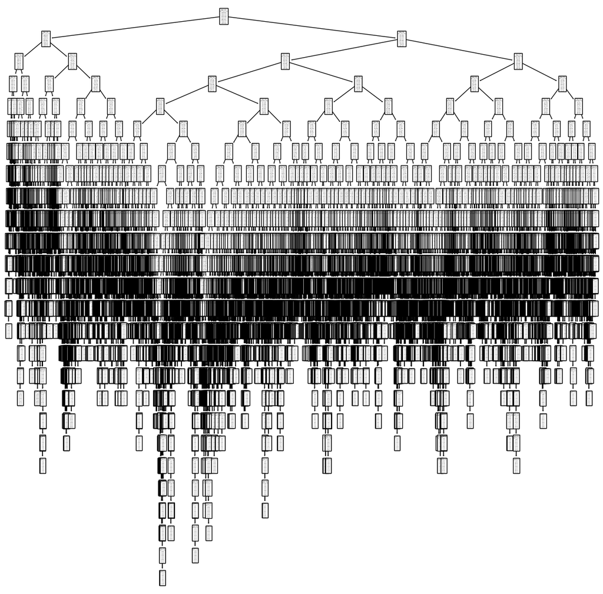

```python
#Run Decision Tree classifier
df_dt = DecisionTreeClassifier(criterion='gini', min_samples_split=2)
df_dt.fit(X_train, y_train)
figure(figsize=(15,15))
tree.plot_tree(df_dt)
```

## Training Set

```python
#What is the training accuracy score? Using the cross-validation method
y_pred_train = df_dt.predict(X_train)
print('Train accuracy score: ',cross_val_score(df_dt, X_train, y_train, cv = 3, scoring='accuracy').mean())
```

```
Train accuracy score:  0.6032418979334652
```

```python
y_pred_train
```

```
array([[0, 1, 1, ..., 0, 0, 0],
       [0, 0, 0, ..., 0, 0, 0],
       [0, 0, 0, ..., 0, 0, 0],
       ...,
       [0, 1, 0, ..., 0, 0, 0],
       [0, 0, 0, ..., 0, 0, 0],
       [0, 1, 0, ..., 0, 0, 0]], dtype=int64)
```

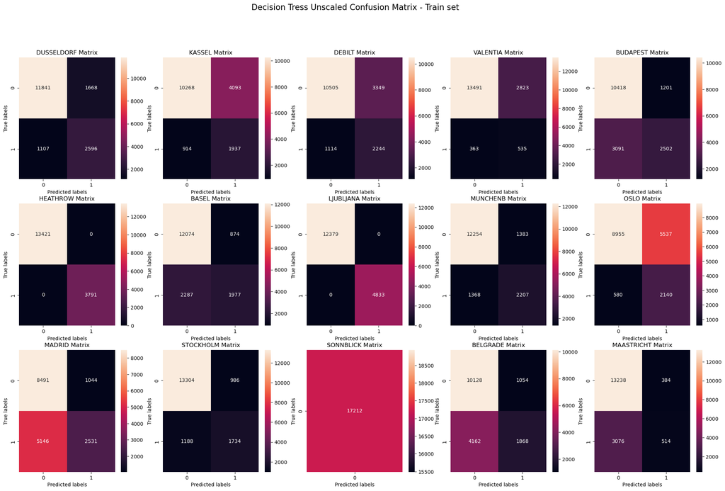

```python
key = "_pleasant_weather"
stations = []
figure, ax = plt.subplots(3, 5, figsize=(25,15))
figure.suptitle('Decision Tress Unscaled Confusion Matrix - Train set', fontsize=16)

labels = ['pleasant', 'unpleasant']
count=0
for i in range(3):
    for j in range(5):
        name = locations_A1[count]
        cm = confusion_matrix(y_train.loc[:,name+key], y_pred_train[:,count])
        disp = ConfusionMatrixDisplay(confusion_matrix=cm)
        ax[i,j] = sns.heatmap(cm, annot=True, fmt='g', ax=ax[i,j]);
        # labels, title and ticks
        ax[i,j].set_xlabel('Predicted labels');
        ax[i,j].set_ylabel('True labels');
        ax[i,j].set_title(name +' Matrix');
        count+=1

plt.savefig('DT_train_confusion_matrix_unscaled.png', bbox_inches='tight')
plt.show()
```

# Do you think the decision tree needs to be pruned? Why?

I've tested this decision tree model convergence matrix several times.  
I've gotten different results each time, but the accuracy is around 0.6.  
It's clear that this model doesn't predict the outcome very well,  
and I think it has something to do with the shape of the decision tree being too complex.  
But I'm not sure if I should prune this model or not.

## Test set

```python
#What is the training accuracy score? Using the cross-validation method
y_pred_test = df_dt.predict(X_test)
print('Test accuracy score: ',cross_val_score(df_dt, X_test, y_test, cv = 3, scoring='accuracy').mean())
```

```
Test accuracy score:  0.5489707980557311
```

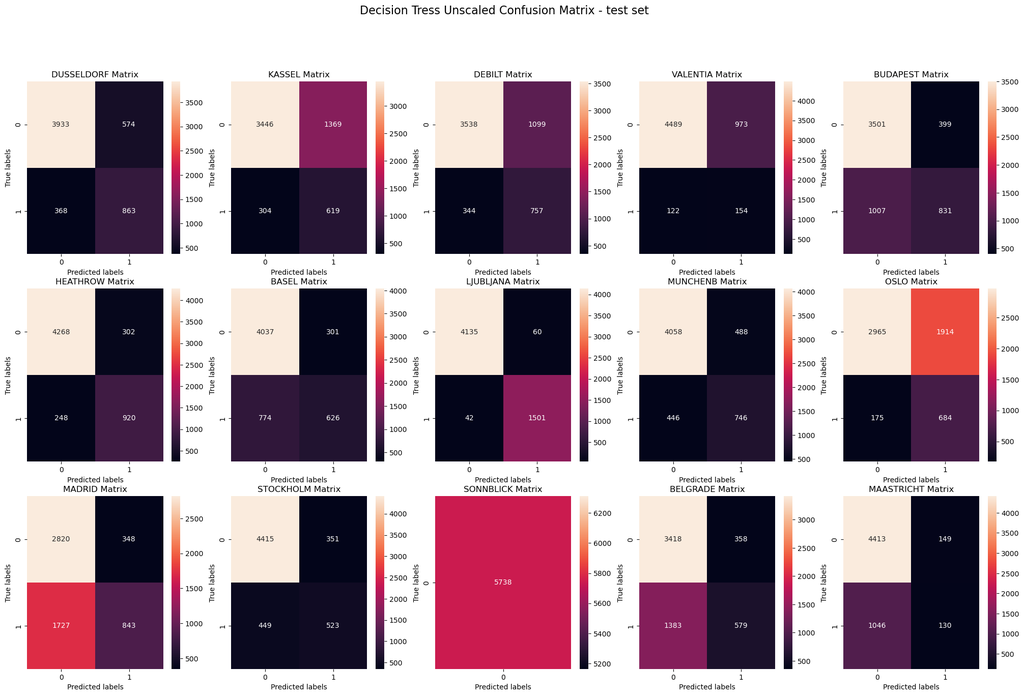

```python
key = "_pleasant_weather"
stations = []
figure, ax = plt.subplots(3, 5, figsize=(25,15))
figure.suptitle('Decision Tress Unscaled Confusion Matrix - test set', fontsize=16)

labels = ['pleasant', 'unpleasant']
count=0
for i in range(3):
    for j in range(5):
        name = locations_A1[count]
        cm = confusion_matrix(y_test.loc[:,name+key], y_pred_test[:,count])
        disp = ConfusionMatrixDisplay(confusion_matrix=cm)
        ax[i,j] = sns.heatmap(cm, annot=True, fmt='g', ax=ax[i,j]);
        # labels, title and ticks
        ax[i,j].set_xlabel('Predicted labels');
        ax[i,j].set_ylabel('True labels');
        ax[i,j].set_title(name +' Matrix');
        #ax[i,j].xaxis.set_ticklabels(labels); #These two lines may throw an error depending on SONNBLICK data. Can you tell why?
        #ax[i,j].yaxis.set_ticklabels(labels);
        count+=1
plt.savefig('DT_test_confusion_matrix_unscaled.png', bbox_inches='tight')
plt.show()
```

# Decision Tree model with Scaled data

[output not shown]

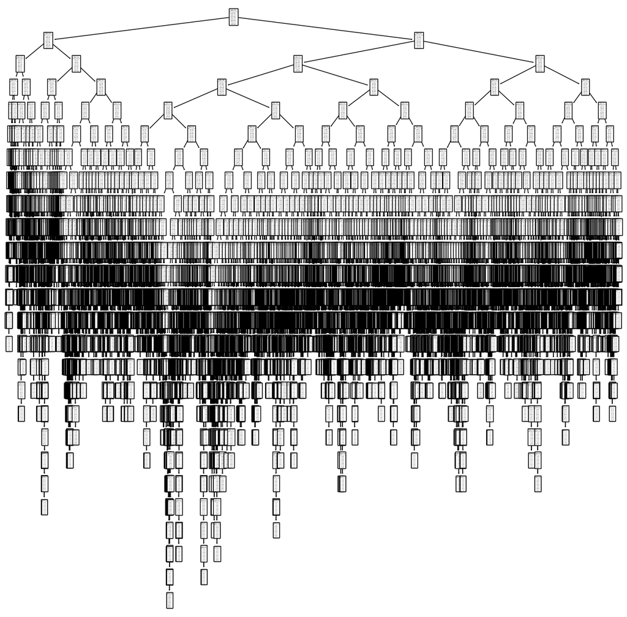

```python
#Run Decision Tree classifier
df_dt_sc = DecisionTreeClassifier(criterion='gini', min_samples_split=2)
df_dt_sc.fit(X_train_sc, y_train_sc)
plt.figure(figsize=(15,15))
tree.plot_tree(df_dt_sc)
```

## Training Set

```python
#What is the training accuracy score? Using the cross-validation method
y_pred_train_sc = df_dt_sc.predict(X_train_sc)
print('Train accuracy score: ',cross_val_score(df_dt_sc, X_train_sc, y_train_sc, cv = 3, scoring='accuracy').mean())
```

```
Train accuracy score:  0.6033581229380264
```

```python
y_pred_train_sc
```

```
array([[0, 1, 1, ..., 0, 0, 0],
       [0, 0, 0, ..., 0, 0, 0],
       [0, 0, 0, ..., 0, 0, 0],
       ...,
       [0, 1, 0, ..., 0, 0, 0],
       [0, 0, 0, ..., 0, 0, 0],
       [0, 1, 0, ..., 0, 0, 0]], dtype=int64)
```

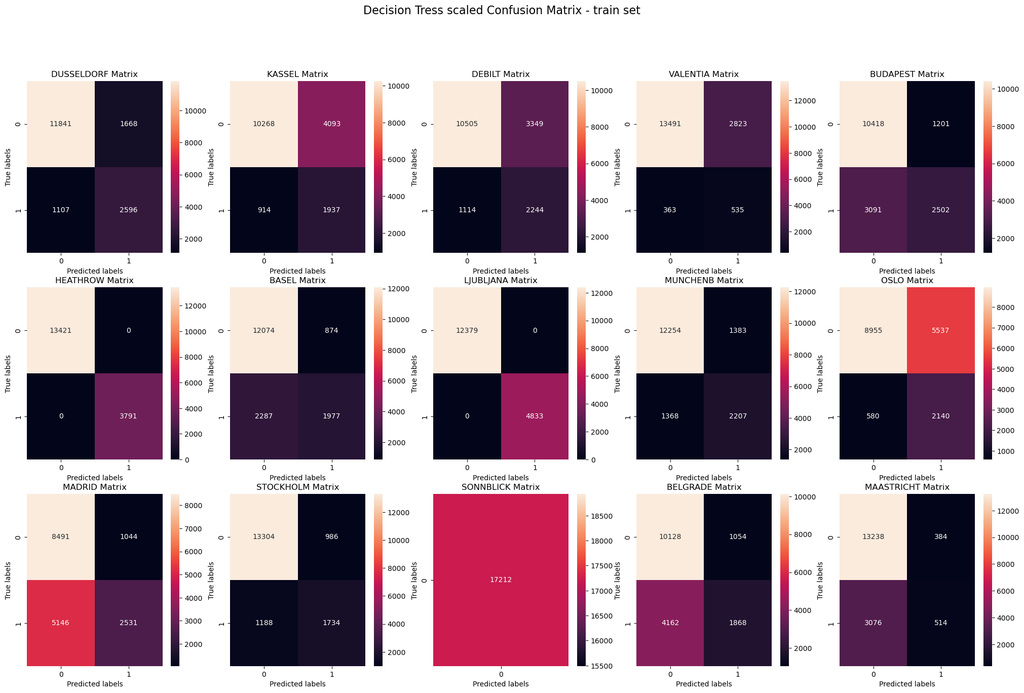

```python
key = "_pleasant_weather"
stations = []
figure, ax = plt.subplots(3, 5, figsize=(25,15))
figure.suptitle('Decision Tress scaled Confusion Matrix - train set', fontsize=16)

labels = ['pleasant', 'unpleasant']
count=0
for i in range(3):
    for j in range(5):
        name = locations_A1[count]
        cm = confusion_matrix(y_train_sc.loc[:,name+key], y_pred_train_sc[:,count])
        disp = ConfusionMatrixDisplay(confusion_matrix=cm)
        ax[i,j] = sns.heatmap(cm, annot=True, fmt='g', ax=ax[i,j]);
        # labels, title and ticks
        ax[i,j].set_xlabel('Predicted labels');
        ax[i,j].set_ylabel('True labels');
        ax[i,j].set_title(name +' Matrix');
        #ax[i,j].xaxis.set_ticklabels(labels); #These two lines may throw an error depending on SONNBLICK data. Can you tell why?
        #ax[i,j].yaxis.set_ticklabels(labels);
        count+=1

plt.savefig('DT_train_confusion_matrix_scaled.png', bbox_inches='tight')
plt.show()
```

## Test set

```python
#What is the training accuracy score? Using the cross-validation method
y_pred_test_sc = df_dt_sc.predict(X_test_sc)
print('Test accuracy score: ',cross_val_score(df_dt_sc, X_test_sc, y_test_sc, cv = 3, scoring='accuracy').mean())
```

```
Test accuracy score:  0.5526306100591927
```

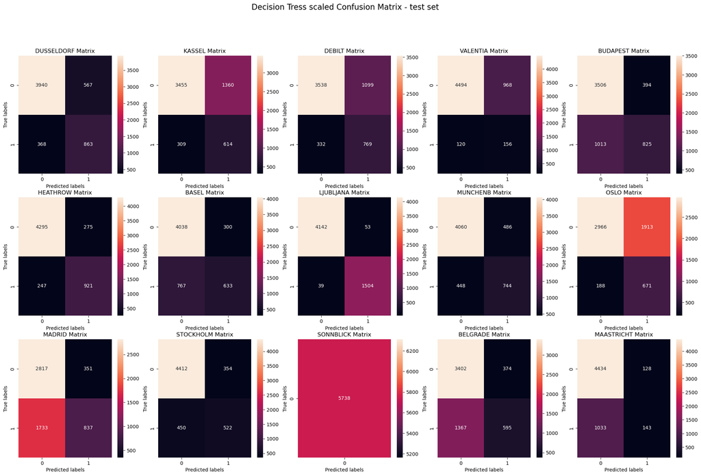

```python
key = "_pleasant_weather"
stations = []
figure, ax = plt.subplots(3, 5, figsize=(25,15))
figure.suptitle('Decision Tress scaled Confusion Matrix - test set', fontsize=16)

labels = ['pleasant', 'unpleasant']
count=0
for i in range(3):
    for j in range(5):
        name = locations_A1[count]
        cm = confusion_matrix(y_test_sc.loc[:,name+key], y_pred_test_sc[:,count])
        disp = ConfusionMatrixDisplay(confusion_matrix=cm)
        ax[i,j] = sns.heatmap(cm, annot=True, fmt='g', ax=ax[i,j]);
        # labels, title and ticks
        ax[i,j].set_xlabel('Predicted labels');
        ax[i,j].set_ylabel('True labels');
        ax[i,j].set_title(name +' Matrix');
        #ax[i,j].xaxis.set_ticklabels(labels); #These two lines may throw an error depending on SONNBLICK data. Can you tell why?
        #ax[i,j].yaxis.set_ticklabels(labels);
        count+=1

plt.savefig('DT_test_confusion_matrix_scaled.png', bbox_inches='tight')
plt.show()
```

# Artificial Neeral Networks (ANNs) Model with Scaled Data

```python
X_train_sc
```

```
array([[-1.41107749, -0.03095027, -0.61660315, ...,  1.45475014,
         1.57581674,  1.16512065],
       [ 1.08186228, -0.58789342,  0.55778807, ..., -0.0139084 ,
        -0.0077553 , -0.00981651],
       [ 0.66637232, -0.866365  ,  0.73846364, ..., -2.92125284,
        -3.22950531, -2.18774879],
       ...,
       [ 0.25088236, -0.03095027,  0.55778807, ..., -0.34360725,
        -0.03505826, -0.58295658],
       [ 0.66637232, -0.03095027, -0.52626537, ...,  0.10598209,
         0.1560625 ,  0.0474975 ],
       [ 0.25088236, -0.44865764, -0.70694094, ..., -0.34360725,
        -0.49920869, -0.15310152]])
```

```python
#Assign the scaled data to DataFrames
X_train_df = pd.DataFrame(X_train_sc, index=X_train.index, columns=X_train.columns)
X_test_df = pd.DataFrame(X_test_sc, index=X_test.index, columns=X_test.columns)
```

```python
X_train_df
```

|  | BASEL_cloud_cover | BASEL_wind_speed | BASEL_humidity | BASEL_pressure | BASEL_global_radiation | BASEL_precipitation | BASEL_snow_depth | BASEL_sunshine | BASEL_temp_mean | BASEL_temp_min | ... | VALENTIA_cloud_cover | VALENTIA_humidity | VALENTIA_pressure | VALENTIA_global_radiation | VALENTIA_precipitation | VALENTIA_snow_depth | VALENTIA_sunshine | VALENTIA_temp_mean | VALENTIA_temp_min | VALENTIA_temp_max |
| --- | --- | --- | --- | --- | --- | --- | --- | --- | --- | --- | --- | --- | --- | --- | --- | --- | --- | --- | --- | --- | --- |
| 8196 | -1.411077 | -0.030950 | -0.616603 | -0.746131 | 1.181615 | -0.321907 | -0.178396 | 0.530475 | 1.352627 | 1.112763 | ... | 0.169208 | 0.059797 | -0.566890 | -0.008427 | -0.146880 | -0.024111 | -0.411551 | 1.454750 | 1.575817 | 1.165121 |
| 20472 | 1.081862 | -0.587893 | 0.557788 | -0.214102 | -0.827240 | -0.262136 | -0.178396 | -1.069706 | -1.652545 | -1.455149 | ... | -0.443416 | -0.080424 | -0.007306 | -1.066874 | -0.003704 | -0.024111 | -0.023323 | -0.013908 | -0.007755 | -0.009817 |
| 18269 | 0.666372 | -0.866365 | 0.738464 | -1.262958 | -1.009863 | -0.301983 | 0.821457 | -0.930560 | -1.652545 | -1.883135 | ... | -0.443416 | 1.041345 | 0.403055 | -0.831663 | -0.422219 | -0.024111 | -0.083050 | -2.921253 | -3.229505 | -2.187749 |
| 7713 | -1.411077 | -0.030950 | -0.164914 | 0.409131 | -0.590904 | -0.441448 | -0.178396 | -0.258020 | -1.598397 | -1.546860 | ... | 1.394457 | 1.181566 | -1.033209 | -1.113916 | 1.284882 | -0.024111 | -1.038689 | -1.182841 | -0.663026 | -1.127440 |
| 21958 | 0.666372 | 3.171473 | -0.616603 | -0.685328 | -0.827240 | 1.909538 | -0.178396 | -0.953751 | -0.583137 | -0.690890 | ... | -0.443416 | -0.080424 | -0.007306 | -0.008427 | -0.003704 | -0.024111 | -0.023323 | -0.013908 | -0.007755 | -0.009817 |
| ... | ... | ... | ... | ... | ... | ... | ... | ... | ... | ... | ... | ... | ... | ... | ... | ... | ... | ... | ... | ... | ... |
| 11964 | 1.081862 | -0.727129 | 1.280490 | -2.479023 | -0.816497 | -0.341830 | -0.178396 | -0.930560 | 0.391514 | 0.883485 | ... | 0.169208 | 0.340239 | 0.253832 | 0.015094 | -0.367152 | -0.024111 | 0.096132 | 0.255845 | 0.565607 | -0.067131 |
| 21575 | 0.250882 | -1.423308 | 0.919139 | -0.411713 | -0.354568 | -0.282059 | -0.178396 | -1.046515 | -1.273514 | -1.103590 | ... | -0.443416 | -0.080424 | -0.007306 | -0.949268 | -0.003704 | -0.024111 | -0.023323 | -0.013908 | -0.007755 | -0.009817 |
| 5390 | 0.250882 | -0.030950 | 0.557788 | -0.001291 | -0.397538 | -0.441448 | -0.178396 | -0.513121 | -0.556063 | -0.431041 | ... | 0.169208 | -1.202193 | 0.813416 | -0.102511 | -0.091813 | -0.024111 | -0.053186 | -0.343607 | -0.035058 | -0.582957 |
| 860 | 0.666372 | -0.030950 | -0.526265 | -0.001291 | 0.977507 | 0.275802 | -0.178396 | 0.228992 | -0.041664 | 0.287363 | ... | 0.781833 | 0.480460 | -0.175181 | 1.038259 | -0.334111 | -0.024111 | 0.275315 | 0.105982 | 0.156062 | 0.047498 |
| 15795 | 0.250882 | -0.448658 | -0.706941 | 0.226721 | -0.139717 | -0.441448 | -0.178396 | -0.443548 | 0.161388 | -0.186478 | ... | 0.781833 | -0.360867 | 0.925332 | 0.309107 | 0.150486 | -0.024111 | -0.292096 | -0.343607 | -0.499209 | -0.153102 |

17212 rows × 147 columns

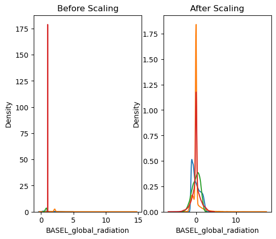

```python
#BASEL_cloud_cover	BASEL_wind_speed	BASEL_humidity	BASEL_pressure	BASEL_global_radiation	BASEL_precipitation	BASEL_snow_depth	BASEL_sunshine	BASEL_temp_mean	BASEL_temp_min

#Show scaling differences
fig, (ax1, ax2) = plt.subplots(ncols=2, figsize=(6, 5))

ax1.set_title('Before Scaling')
sns.kdeplot(X_train['BASEL_global_radiation'], ax=ax1)
sns.kdeplot(X_train['BASEL_wind_speed'], ax=ax1)
sns.kdeplot(X_train['BASEL_humidity'], ax=ax1)
sns.kdeplot(X_train['BASEL_pressure'], ax=ax1)

ax2.set_title('After Scaling')
sns.kdeplot(X_train_df['BASEL_global_radiation'], ax=ax2)
sns.kdeplot(X_train_df['BASEL_wind_speed'], ax=ax2)
sns.kdeplot(X_train_df['BASEL_humidity'], ax=ax2)
sns.kdeplot(X_train_df['BASEL_pressure'], ax=ax2)

plt.show()
```

```python
#Create the ANN
#hidden_layer_sizes has up to three layers, each with a number of nodes. So (5, 5) is two hidden layers with 5 nodes each,
#and (100, 50, 25) is three hidden layers with 100, 50, and 25 nodes.
mlp = MLPClassifier(hidden_layer_sizes=(5, 5), max_iter=500, tol=0.0001)
#Fit the data to the model
mlp.fit(X_train_sc, y_train_sc)
```

```
MLPClassifier(hidden_layer_sizes=(5, 5), max_iter=500)
```

```python
#how accurate it is.
y_pred_sc = mlp.predict(X_train_sc)
print(accuracy_score(y_pred_sc, y_train_sc))
y_pred_test_sc = mlp.predict(X_test_sc)
print(accuracy_score(y_pred_test_sc, y_test_sc))
```

```
0.4861143388333721
0.49302892994074593
```

```python
#more complicated network
#Create the ANN
#hidden_layer_sizes has up to three layers, each with a number of nodes. So (5, 5) is two hidden layers with 5 nodes each,
#and (100, 50, 25) is three hidden layers with 100, 50, and 25 nodes.
mlp = MLPClassifier(hidden_layer_sizes=(10, 5), max_iter=500, tol=0.0001)
#Fit the data to the model
mlp.fit(X_train_sc, y_train_sc)
```

```
MLPClassifier(hidden_layer_sizes=(10, 5), max_iter=500)
```

```python
#how accurate it is.
y_pred_sc = mlp.predict(X_train_sc)
print(accuracy_score(y_pred_sc, y_train_sc))
y_pred_test_sc = mlp.predict(X_test_sc)
print(accuracy_score(y_pred_test_sc, y_test_sc))
```

```
0.5277132233325587
0.5298013245033113
```

```python
# the other model
#Create the ANN
#hidden_layer_sizes has up to three layers, each with a number of nodes. So (5, 5) is two hidden layers with 5 nodes each,
#and (100, 50, 25) is three hidden layers with 100, 50, and 25 nodes.
mlp = MLPClassifier(hidden_layer_sizes=(20, 10, 10), max_iter=1000, tol=0.0001)
#Fit the data to the model
mlp.fit(X_train_sc, y_train_sc)
```

```
MLPClassifier(hidden_layer_sizes=(20, 10, 10), max_iter=1000)
```

```python
#how accurate it is.
y_pred_sc = mlp.predict(X_train_sc)
print(accuracy_score(y_pred_sc, y_train_sc))
y_pred_test_sc = mlp.predict(X_test_sc)
print(accuracy_score(y_pred_test_sc, y_test_sc))
```

```
0.6261329305135952
0.6071802021610317
```

```python
# the other model
#Create the ANN
#hidden_layer_sizes has up to three layers, each with a number of nodes. So (5, 5) is two hidden layers with 5 nodes each,
#and (100, 50, 25) is three hidden layers with 100, 50, and 25 nodes.
mlp = MLPClassifier(hidden_layer_sizes=(100, 50, 25), max_iter=1000, tol=0.0001)
#Fit the data to the model
mlp.fit(X_train_sc, y_train_sc)
```

```
MLPClassifier(hidden_layer_sizes=(100, 50, 25), max_iter=1000)
```

```python
#how accurate it is.
y_pred_sc = mlp.predict(X_train_sc)
print(accuracy_score(y_pred_sc, y_train_sc))
y_pred_test_sc = mlp.predict(X_test_sc)
print(accuracy_score(y_pred_test_sc, y_test_sc))
```

```
0.8148384847780619
0.5928895085395608
```

### Confusion Matrix Train set

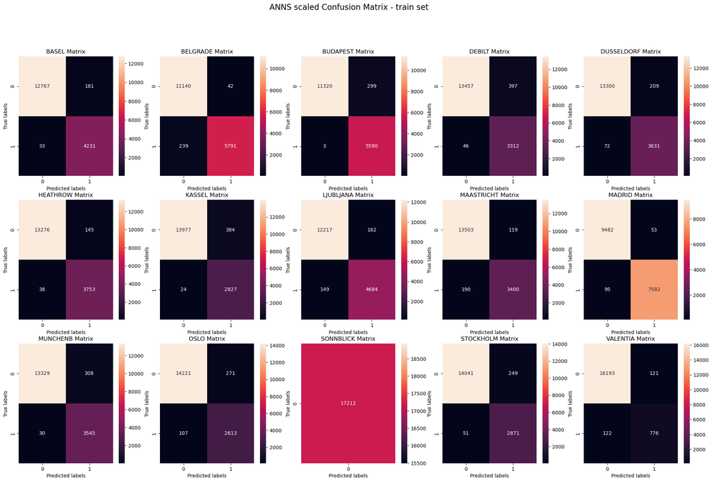

```python
key = "_pleasant_weather"
stations = []
figure, ax = plt.subplots(3, 5, figsize=(25,15))
figure.suptitle('ANNS scaled Confusion Matrix - train set', fontsize=16)

labels = ['pleasant', 'unpleasant']
count=0
for i in range(3):
    for j in range(5):
        name = locations_B[count]
        cm = confusion_matrix(y_train_sc.loc[:,name+key], y_pred_sc[:,count])
        disp = ConfusionMatrixDisplay(confusion_matrix=cm)
        ax[i,j] = sns.heatmap(cm, annot=True, fmt='g', ax=ax[i,j]);
        # labels, title and ticks
        ax[i,j].set_xlabel('Predicted labels');
        ax[i,j].set_ylabel('True labels');
        ax[i,j].set_title(name +' Matrix');
        #ax[i,j].xaxis.set_ticklabels(labels); #These two lines may throw an error depending on SONNBLICK data. Can you tell why?
        #ax[i,j].yaxis.set_ticklabels(labels);
        count+=1

plt.savefig('ANN_train_confusion_matrix_scaled.png', bbox_inches='tight')
plt.show()
```

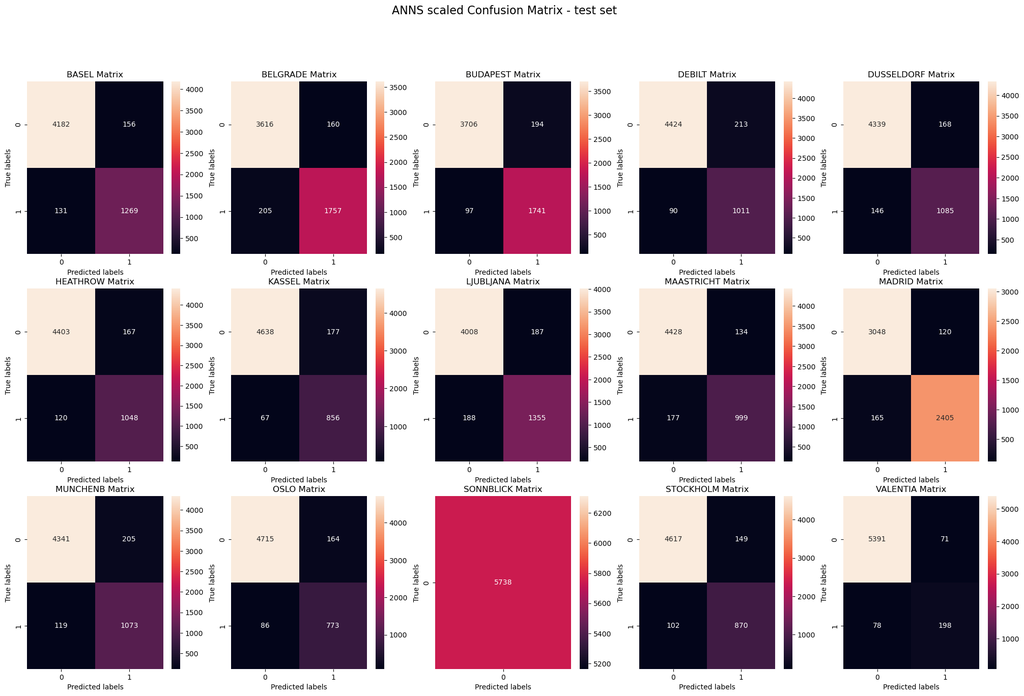

```python
key = "_pleasant_weather"
stations = []
figure, ax = plt.subplots(3, 5, figsize=(25,15))
figure.suptitle('ANNS scaled Confusion Matrix - test set', fontsize=16)

labels = ['pleasant', 'unpleasant']
count=0
for i in range(3):
    for j in range(5):
        name = locations_B[count]
        cm = confusion_matrix(y_test_sc.loc[:,name+key], y_pred_test_sc[:,count])
        disp = ConfusionMatrixDisplay(confusion_matrix=cm)
        ax[i,j] = sns.heatmap(cm, annot=True, fmt='g', ax=ax[i,j]);
        # labels, title and ticks
        ax[i,j].set_xlabel('Predicted labels');
        ax[i,j].set_ylabel('True labels');
        ax[i,j].set_title(name +' Matrix');
        #ax[i,j].xaxis.set_ticklabels(labels); #These two lines may throw an error depending on SONNBLICK data. Can you tell why?
        #ax[i,j].yaxis.set_ticklabels(labels);
        count+=1

plt.savefig('ANN_test_confusion_matrix_scaled.png', bbox_inches='tight')
plt.show()
```

### Which of these algorithms (including the KNN model from Exercise 1.4) do you think best predicts the current data?

Since the ANNs model was the most accurate, I believe it is the best fit for this data.

### Are there certain features of the data set that might contribute to the overall accuracy?

I don't know much about this.

### Which model would you recommend that ClimateWins use?

If you want to tune the layers of the ANNs model to improve the accuracy on the test set, I would recommend using the ANNs model.